# Position Adjustments

## Exercise

1. What is the problem with this plot? How could you improve it?

   ```r
   ggplot(data = mpg, mapping = aes(x = cty, y = hwy)) +
     geom_point()
   ```

2. What parameters to `geom_jitter()` control the amount of jittering?
3. Compare the contrast `geom_jitter()` with `geom_count()`.
4. What’s default position adjustment for `geom_boxplot`? Create a visualization of the `mpg` dataset that demonstrates it.

**1**

> 1. What is the problem with this plot? How could you improve it?

```r
ggplot(data = mpg, mapping = aes(x = cty, y = hwy)) +
  geom_point()
```

There is overlapping because there are multiple observation for each combination of `cty` and `hwy` values.

I would improve the plot by using a jitter position adjustment to decrease overplotting.

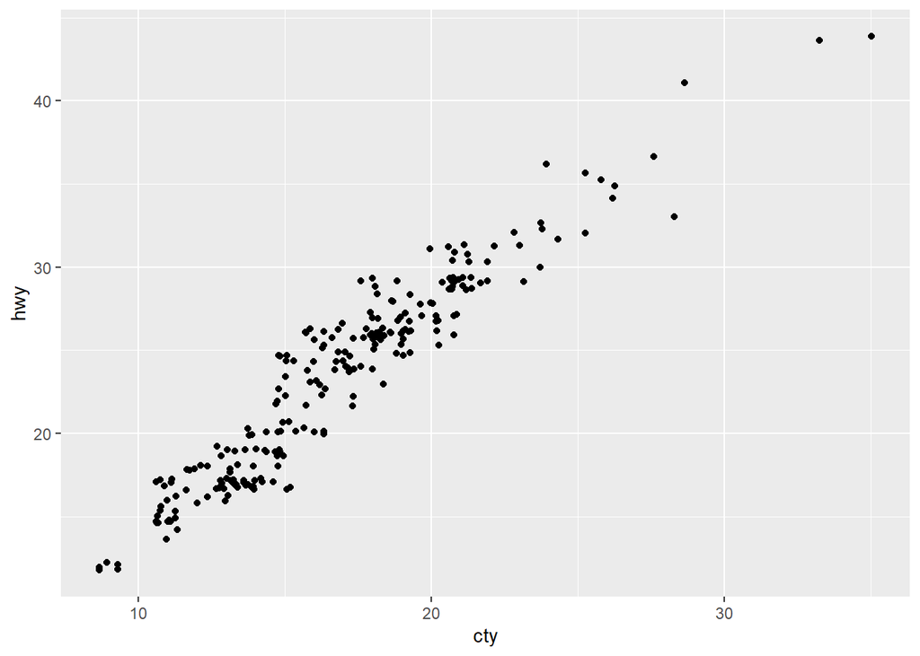

```r
ggplot(data = mpg, mapping = aes(x = cty, y = hwy)) +
  geom_point(position = "jitter")
```

The relationship between the `cty` and `hwy` is clear even without jittering the points but jittering shows the location where there are more observations

**2**

> 1. What parameters to `geom_jitter()` control the amount of jittering?

From the `geom_jitter()` documentation , there are two different arguments to jitter:

- `width` controls the amount of horizontal displacement, and
- `height` controls the amount of vertical displacement

The defaults values of `width` and `height` will introduce noise in both directions, here is what the plot looks like with the defauts values of `height` and `width`.

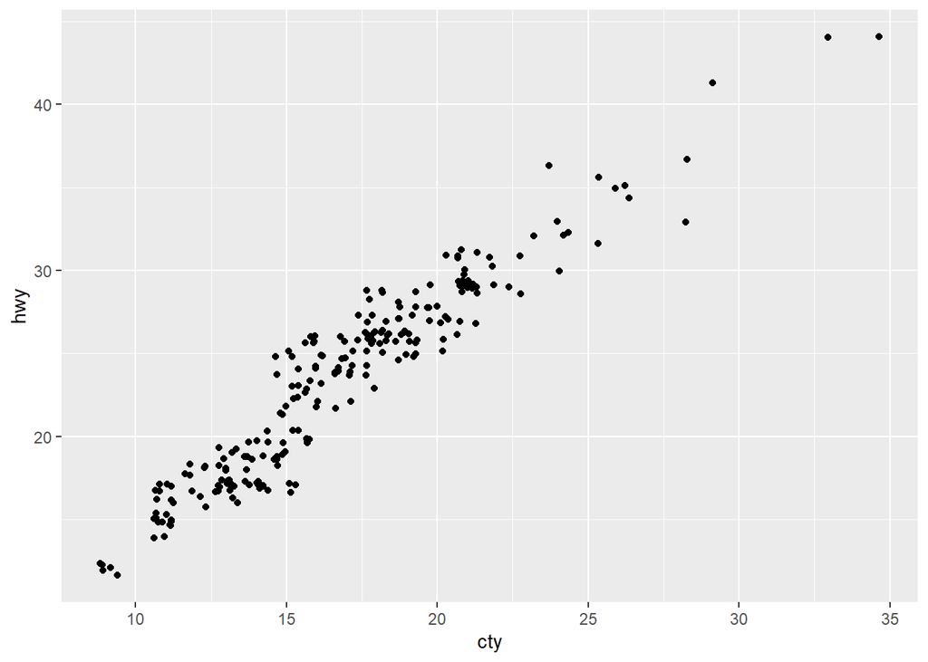

```r
ggplot(data = mpg) +
  geom_point(mapping = aes(x = cty, y = hwy),
             position = position_jitter())
```

However, we can change these parameters. Here are few a examples to understand how these parameters affect the amount of jittering. When `width = 0` there is no horizontal jitter.

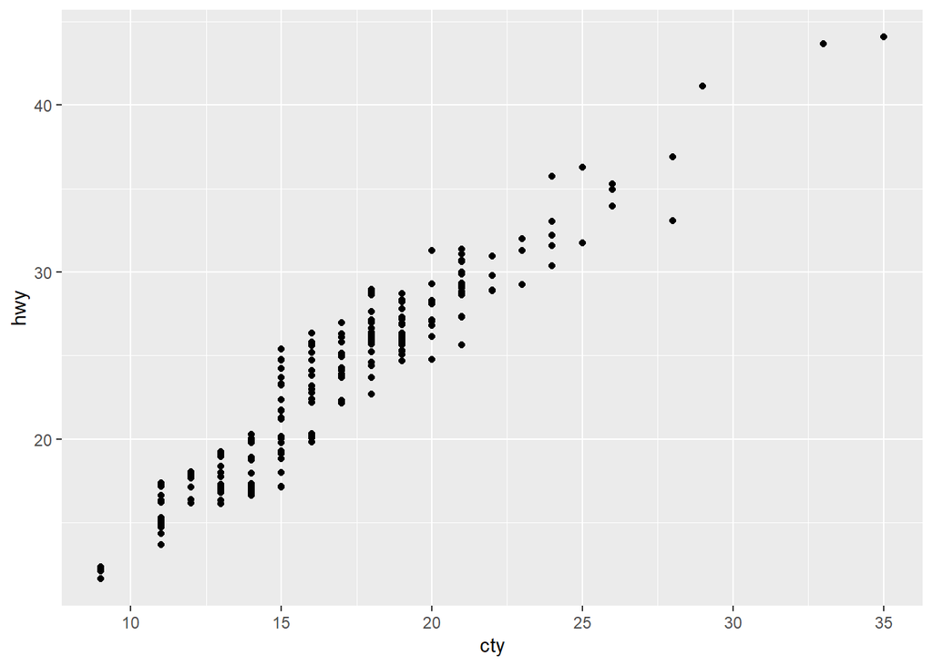

```r
ggplot(data = mpg, mapping = aes(x = cty, y = hwy)) +
  geom_jitter(width = 0)
```

when `width = 20` , there is too much horizontal jitter.

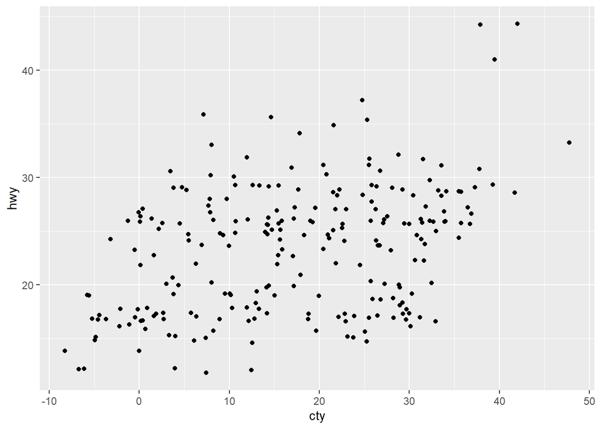

```r
ggplot(data = mpg, mapping = aes(x = cty, y = hwy)) +
  geom_jitter(width = 20)
```

When `height = 0`, there is no vertical jitter.

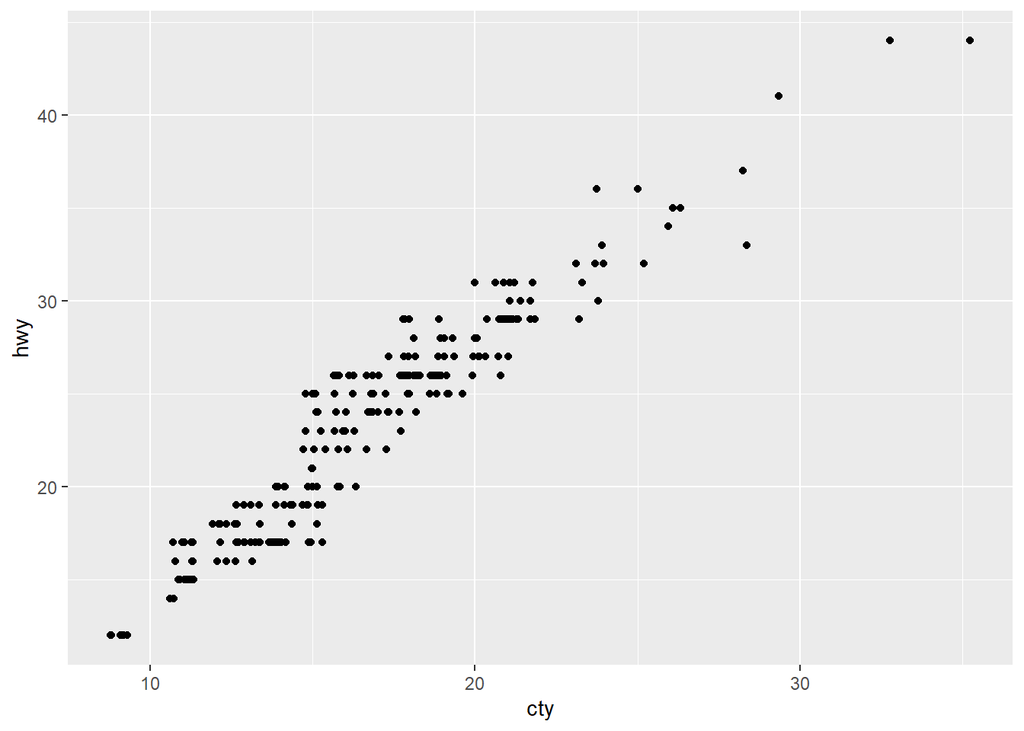

```r
ggplot(data = mpg, mapping = aes(x = cty, y = hwy)) +
  geom_jitter(height = 0)
```

When `height = 15`, there is too much vertical jitter.

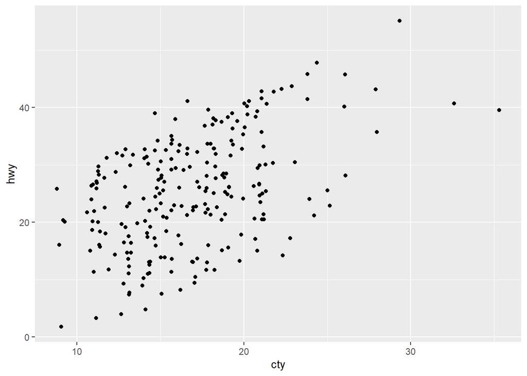

```r
ggplot(data = mpg, mapping = aes(x = cty, y = hwy)) +
  geom_jitter(height = 15)
```

When `width = 0` and `height = 0`, there is neither horizontal or vertical jitter and the plot produced is identical to the one produced with `geom_point()`

```r
ggplot(data = mpg, mapping = aes(x = cty, y = hwy)) +
  geom_jitter(height = 0, width = 0)
```

[output not shown]

Note that the `height` and `width` arguments are in the units of the data. Thus `height = 1` (`width = 1`) corresponds to different relative amounts of jittering depending on the scale of the `y` (`x`) variable. The default value of `height` and `width` are defined to be 80% of the `resolution()` of the data, which is the smallest non-zero distance between adjacent values of a variable. When `x` and `y` are discrete variables, their resolutions are both equal to 1, and `height = 0.4` and `width = 0.4` since the jitter moves points in both positive and negative directions.

The default values of `height` and `width` in `geom_jitter()` are non-zero, so unless both `height` and `width` are explicitly set 0, there will be some jitter.

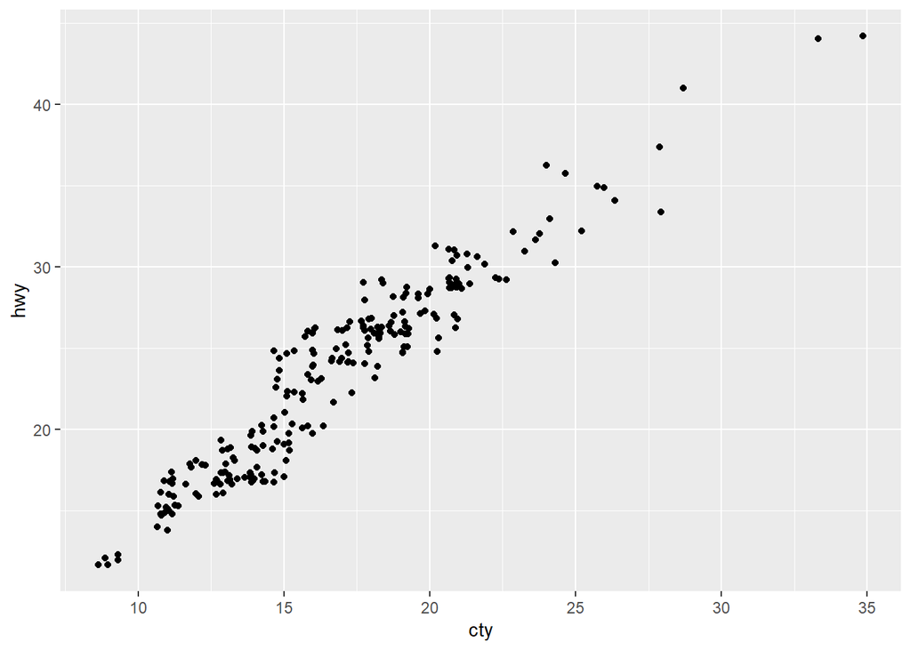

```r
ggplot(data = mpg, mapping = aes(x = cty, y = hwy)) +
  geom_jitter()
```

**3**

> Compare the contrast `geom_jitter()` with `geom_count()`.

The geom `geom_jitter()` adds random variation to the locations points of the graph. In other words, it “jitters” the location of points slightly. This method reduces overplotting since two points with the same location are unlikely to have the same random variation.

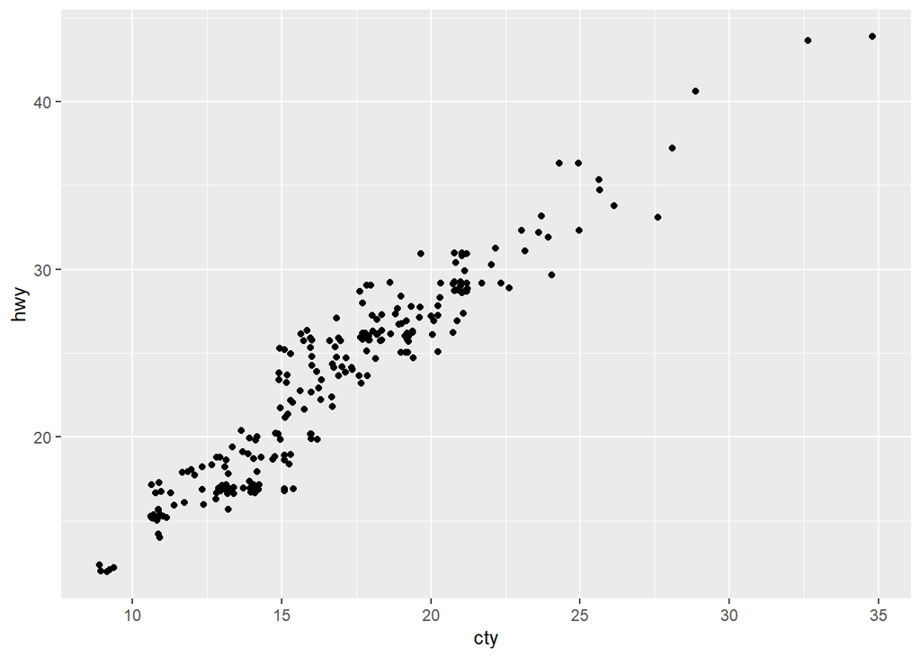

```r
ggplot(data = mpg, mapping = aes(x = cty, y = hwy)) +
  geom_jitter()
```

However, the reduction in overlapping comes at the cost of slightly changing the `x` and `y` values of the points.

The geom `geom_count()` sizes the points relative to the number of observations. Combinations of (`x`, `y`) values with more observations will be larger than those with fewer observations.

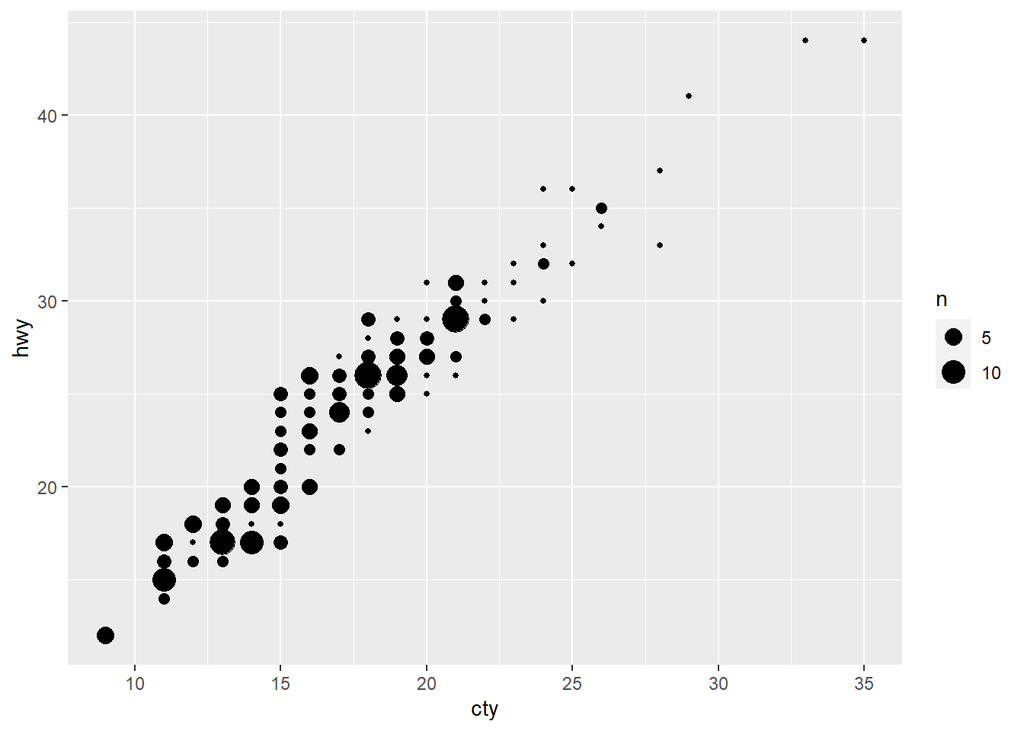

```r
ggplot(data = mpg, mapping = aes(x = cty, y = hwy)) +
  geom_count()
```

The `geom_count()` geom does not change `x` and `y` coordinates of the points. However, if the points are close together and counts are large, the size of some points can itself create overplotting. For example, in the following example, a third variable mapped to color is added to the plot. In this case, `geom_count()` is less readable than `geom_jitter()` when adding a third variable as a color aesthetic.

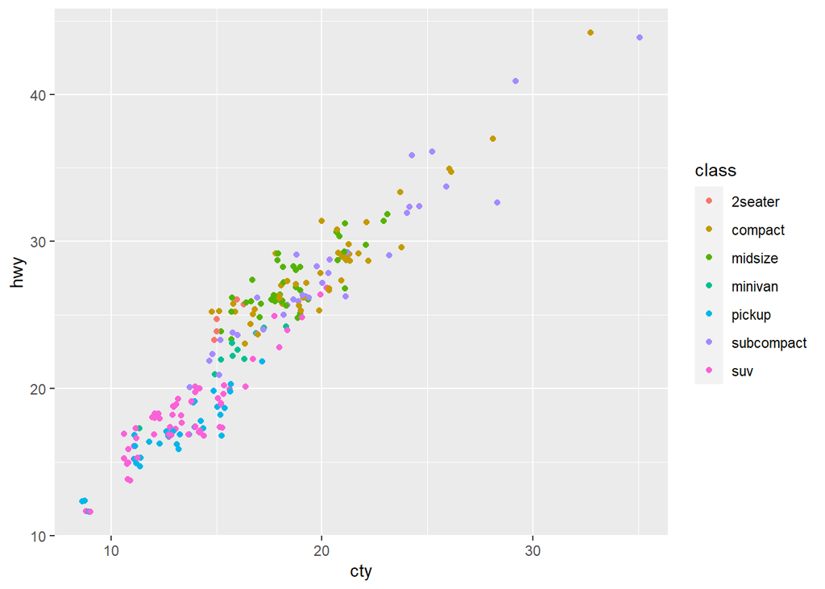

```r
ggplot(data = mpg, mapping = aes(x = cty, y = hwy, color = class)) +
  geom_jitter()
```

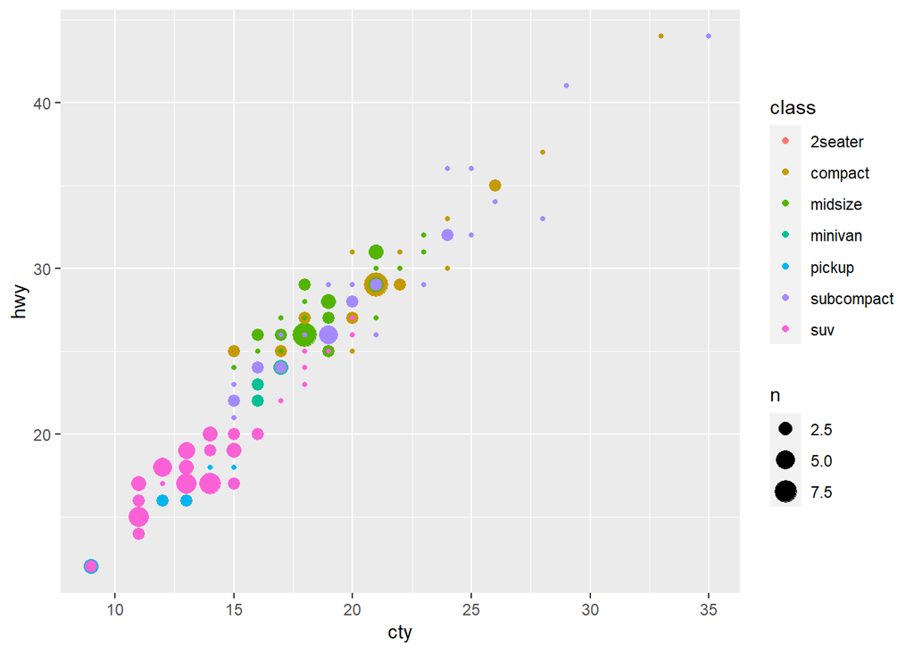

```r
ggplot(data = mpg, aes(x = cty, y = hwy, color = class)) +
  geom_count()
```

Combining `geom_count()` with jitter, which is specified with the `position` argument to `geom_count()` rather than its own geom, helps overplotting a little.

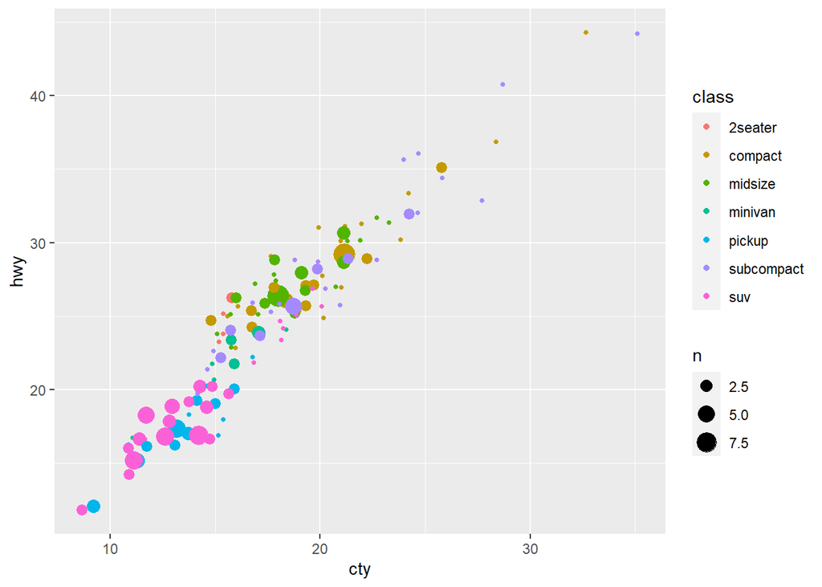

```r
ggplot(data = mpg, mapping = aes(x = cty, y = hwy, color = class)) +
  geom_count(position = "jitter")
```

But as this example shows, unfortunately, there is no universal solution to overplotting. The costs and benefits approaches will depend on the structure of the data and the goal of the data scientist.

**4**

> What’s default position adjustment for `geom_boxplot`? Create a visualization of the `mpg` dataset that demonstrates it.

The default position for `geom_boxplot()` is `"dodge2"`, which is a shortcut for `position_dodge2`. This position adjustment does not change the vertical position of geom but moves the geom horizontally to avoid overlapping other geoms.

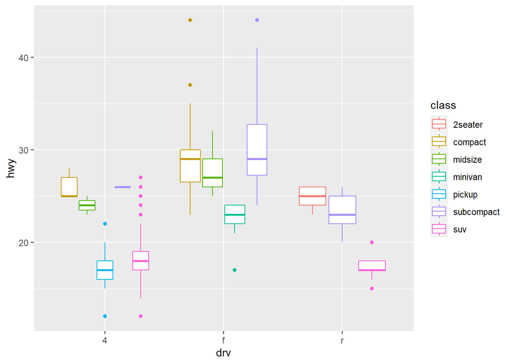

```r
ggplot(data = mpg, mapping = aes(x = drv, y = hwy, color = class)) +
  geom_boxplot()
```

If `position_identity()` is used the boxplots overlap.

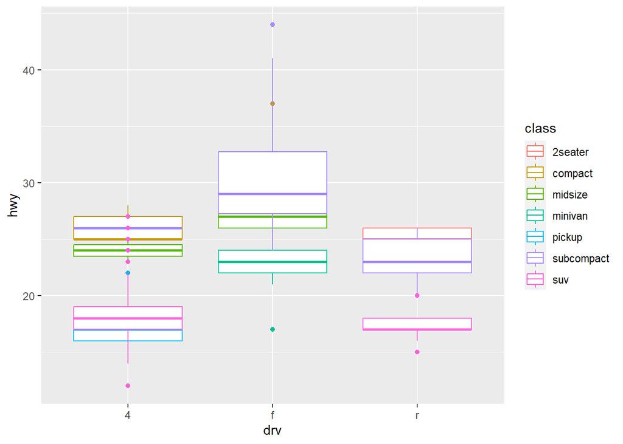

```r
ggplot(data = mpg, aes(x = drv, y = hwy, color = class)) +
  geom_boxplot(position = "identity")
```